# UFC Fight Analysis

**By: Courtney Ferguson Lee**

[figure not shown]

# Introduction

# Background

The Ultimate Fighting Championship (UFC) is a mixed martial arts fighting organization based out of Las Vegas, Nevada. Founded in 1992, it's original goal was to pit fighters from around the world against each other to see which fighting style was the best. In the beginning, there were no rules and there were no weight classes. Eye gouges, groin strikes, headbutts and biting were all legal. Fighters weighing 160 lbs would get tossed in against 400 lbs behemoths. This type of no holds bar contest had never been attempted before and it quickly gained notoriety for its brutality.

It also gave rise to a new way of thinking about fighting. When kung-fu masters, boxers, kickboxers, and karate experts all met for the first time, no one could have predicted the outcome. Most people expected the larger, more gruesome-looking fighters to win. To everyone's shock, it was an unassuming 178 pound man named Royce Gracie who would go on to win the first contest. What was even stranger was that no one could explain how he won the first time (or the second or the third). He didn't pummel his opponent into submission as expected, but instead locked him up using wrestling moves most people hadn't seen before. This was the world's introduction to Brazillian Jiu Jitsu (BJJ).

After Royce went on to win several UFC contests, people began to realize he was not just getting lucky. Fighters started studying this martial art so they could start applying these techniques in their matches or at the very least prevent themselves from being submitted by Royce. Then, they started adding techniques from other fighting styles so that they, too could become the best in the world. This was the beginning of mixed martial arts or MMA. It started out with a multitude of different styles, but a handful started to show up repeatedly: BJJ, wrestling, boxing and kickboxing. Over time, fighters' skill in these 4 areas evolved to where no one art was able to completely dominate the others.

Now, the UFC is watched by millions worldwide and its support continues to grow. The rules were changed to protect the safety of the fighters. You can no longer gouge your opponent's eyes or pull hair or bite. All fighters are now required to wear standard MMA gloves and shoes are no longer allowed in the octagon. There are now weight classes that range from 115 lbs all the way up to 265. A lot has changed in the UFC and this project seeks to determine which components matter most in a match.

[figure not shown]

# Data

The data was scraped from www.fightmetrics.com with Beautiful Soup in two stages. The first script compiled a list of event urls and wrote them to a CSV. The second script crawled through those urls and extracted all available fight data into a pandas dataframe. There are 31 features and 8624 records.

During our exploration, we'll examine the data from several perspectives. We'll put it under a microscope through univariate analysis, get a bird's eye view using a correlation matrix and view it from ringside through multivariate analysis.

```python
# Imports and Helper Functions
# data Analysis
import pandas as pd
pd.options.display.max_columns = 50
pd.options.display.max_colwidth = 75
from IPython.display import display
import seaborn as sns
import numpy as np
from pprint import pprint
from scipy.stats import norm
color = sns.color_palette()
import random

# Web Scraping
import json
import codecs
import csv
import datetime
from bs4 import BeautifulSoup
import requests
import cStringIO
import pprint

# Visualization
%matplotlib inline
import matplotlib.pyplot as plt
import seaborn as sns
sns.set_style("white")
from PIL import Image
from wordcloud import WordCloud

#SciKit Learn Models
from sklearn.linear_model import LogisticRegression
from sklearn.svm import SVC, LinearSVC
from sklearn.ensemble import RandomForestClassifier
from sklearn.neighbors import KNeighborsClassifier
from sklearn.naive_bayes import GaussianNB
from sklearn.linear_model import Perceptron
from sklearn.linear_model import SGDClassifier
from sklearn.tree import DecisionTreeClassifier
from sklearn.metrics import accuracy_score, precision_score, recall_score, classification_report, confusion_matrix

from subprocess import check_output
print check_output(["ls", "data"]).decode("utf8")
fight_data = pd.read_csv("data/fights_v5.csv")
fight_df = pd.DataFrame(fight_data)
# Any results you write to the current directory are saved as output.

# Noteboook Functionality
#from IPython.core.interactiveshell import InteractiveShell # All statements are printed to output
#InteractiveShell.ast_node_interactivity = "all"
```

```
chunks
fight_urls.csv
fight_urls_backup.csv
fights_v1.csv
fights_v2.csv
fights_v3.csv
fights_v4.csv
fights_v5.csv
```

```python
fight_df.info()
```

```
<class 'pandas.core.frame.DataFrame'>
RangeIndex: 8624 entries, 0 to 8623
Data columns (total 31 columns):
body                 8624 non-null int64
body_attempts        8624 non-null int64
clinch               8624 non-null int64
clinch_attempts      8624 non-null int64
date                 8624 non-null object
distance             8624 non-null int64
distance_attempts    8624 non-null int64
fight_id             8624 non-null int64
ground               8624 non-null int64
ground_attempts      8624 non-null int64
head                 8624 non-null int64
head_attempts        8624 non-null int64
kd                   8624 non-null int64
leg                  8624 non-null int64
leg_attempts         8624 non-null int64
location             8624 non-null object
method               8624 non-null object
name                 8624 non-null object
pass                 8624 non-null int64
referee              8590 non-null object
reversals            8624 non-null int64
round                8624 non-null int64
sig_attempts         8624 non-null int64
sig_strikes          8624 non-null int64
strike_attempts      8624 non-null int64
strikes              8624 non-null int64
sub_attempts         8624 non-null int64
takedowns            8624 non-null int64
td_attempts          8624 non-null int64
title                8624 non-null object
win/loss             8624 non-null object
dtypes: int64(24), object(7)
memory usage: 2.0+ MB
```

```python
fight_df.skew()
```

```
body                 2.347035
body_attempts        2.236733
clinch               2.986340
clinch_attempts      2.798223
distance             2.178721
distance_attempts    1.774613
fight_id             0.002737
ground               3.274183
ground_attempts      3.102702
head                 1.880800
head_attempts        1.605491
kd                   2.611867
leg                  2.681679
leg_attempts         2.685116
pass                 2.941130
reversals            3.667900
round                0.178339
sig_attempts         1.453970
sig_strikes          1.585119
strike_attempts      1.015091
strikes              1.373212
sub_attempts         2.841962
takedowns            2.407126
td_attempts          1.915120
dtype: float64
```

```python
fight_df.describe(include=['O'])
```

|  | date | location | method | name | referee | title | win/loss |
| --- | --- | --- | --- | --- | --- | --- | --- |
| count | 8624 | 8624 | 8624 | 8624 | 8590 | 8624 | 8624 |
| unique | 407 | 136 | 8 | 1684 | 155 | 411 | 4 |
| top | November 19, 2016 | Las Vegas, Nevada, USA | Decision | Michael Bisping | Herb Dean | UFC Fight Night: Belfort vs Henderson | W |
| freq | 50 | 2226 | 3732 | 27 | 1292 | 48 | 4237 |

## Observations

Most of the variables have low means and large maximum values, which means they are probably highly skewed to the right. It might make sense to apply a log transform to some of the distributions when conducting the univariate analysis.

## Missing Data

```python
percent_missing = (fight_df.isnull().sum()/fight_df.isnull().count()).sort_values()
percent_missing
```

```
body                 0.000000
td_attempts          0.000000
takedowns            0.000000
sub_attempts         0.000000
strikes              0.000000
strike_attempts      0.000000
sig_strikes          0.000000
sig_attempts         0.000000
round                0.000000
reversals            0.000000
pass                 0.000000
name                 0.000000
method               0.000000
title                0.000000
location             0.000000
leg                  0.000000
kd                   0.000000
head_attempts        0.000000
head                 0.000000
ground_attempts      0.000000
ground               0.000000
fight_id             0.000000
distance_attempts    0.000000
distance             0.000000
date                 0.000000
clinch_attempts      0.000000
clinch               0.000000
body_attempts        0.000000
leg_attempts         0.000000
win/loss             0.000000
referee              0.003942
dtype: float64
```

# Minor Aesthetics

Before diving deeper into the dataset, let's take a moment to fix a few minor details.

## Rearranging Columns

It bugs me slightly that each fighter's name is buried in the middle of the dataframe. The analysis will be a lot simpler if that information was the first thing we saw in each row. Let's take care of that and move the win/loss column to the front as well.

```python
# Creates a copy of the dataframe for testing
fight_df = pd.DataFrame(fight_data.copy())

# Rearranges the columns so the name, date, fight_id, win/loss and method appear first
cols = fight_df.columns.tolist()
cols = cols[17:18] + cols[4:5] + cols[7:8] + cols[-1:] + cols[16:17] + cols[:4] + cols[5:7] + cols[8:16] + cols[18:-1]

fight_df = fight_df[cols]

# Sets the index as the fight_id
# fight_df.set_index('fight_id', inplace=True)

# Change kd to knock_down for readability
fight_df.rename(columns={'kd': 'knockdowns'}, inplace=True)
```

```python
fight_df.tail()
```

|  | name | date | fight_id | win/loss | method | body | body_attempts | clinch | clinch_attempts | distance | distance_attempts | ground | ground_attempts | head | head_attempts | knockdowns | leg | leg_attempts | location | pass | referee | reversals | round | sig_attempts | sig_strikes | strike_attempts | strikes | sub_attempts | takedowns | … |
| --- | --- | --- | --- | --- | --- | --- | --- | --- | --- | --- | --- | --- | --- | --- | --- | --- | --- | --- | --- | --- | --- | --- | --- | --- | --- | --- | --- | --- | --- | --- |
| 8619 | Art Jimmerson | November 12, 1993 | 4335 | L | Submission | 0 | 0 | 0 | 0 | 0 | 0 | 0 | 0 | 0 | 0 | 0 | 0 | 0 | Denver, Colorado, USA | 0 | Joao Barreto | 0 | 1 | 0 | 0 | 0 | 0 | 0 | 0 | … |
| 8620 | Kevin Rosier | November 12, 1993 | 4336 | W | KO/TKO | 3 | 4 | 4 | 9 | 4 | 10 | 7 | 8 | 12 | 23 | 2 | 0 | 0 | Denver, Colorado, USA | 0 | Joao Barreto | 0 | 1 | 27 | 15 | 53 | 38 | 0 | 0 | … |
| 8621 | Zane Frazier | November 12, 1993 | 4336 | L | KO/TKO | 3 | 6 | 10 | 19 | 0 | 7 | 2 | 2 | 7 | 19 | 0 | 2 | 3 | Denver, Colorado, USA | 0 | Joao Barreto | 0 | 1 | 28 | 12 | 29 | 13 | 0 | 0 | … |
| 8622 | Gerard Gordeau | November 12, 1993 | 4337 | W | KO/TKO | 0 | 0 | 0 | 0 | 1 | 3 | 2 | 2 | 3 | 5 | 0 | 0 | 0 | Denver, Colorado, USA | 0 | Joao Barreto | 0 | 1 | 5 | 3 | 5 | 3 | 0 | 0 | … |
| 8623 | Teila Tuli | November 12, 1993 | 4337 | L | KO/TKO | 0 | 0 | 0 | 0 | 0 | 1 | 0 | 0 | 0 | 1 | 0 | 0 | 0 | Denver, Colorado, USA | 0 | Joao Barreto | 0 | 1 | 1 | 0 | 1 | 0 | 0 | 0 | … |

## Rearranging Fights in Chronological Order

Right off the bat I can see the data is organized in reverse-chronological order. Art Jimmerson fought in the first UFC event and I still remember him because he fought with one boxing glove. It was a crazy time... I'll reverse the dataframe so it's in chronological order and re-index the records.

I'm surprised by the lack of NaN values in this dataset. Apparently, Fightmetrics is very organized! I'll have to crawl deep to see if there are any inconsistencies.

```python
fight_df['fight_id'] = abs(4337 - fight_df['fight_id'])
fight_df = fight_df[::-1]
index = list(range(len(fight_df)))
fight_df.index = index
fight_df['outcome'] = 0
fight_df.loc[fight_df['win/loss'] == 'W', 'outcome'] = 1
```

Let's format the date column as datetime objects while we're at it.

```python
fight_df.loc[:, 'date'] = pd.to_datetime(fight_df.date)
all_fights = fight_df.copy()
fight_df.head()
```

|  | name | date | fight_id | win/loss | method | body | body_attempts | clinch | clinch_attempts | distance | distance_attempts | ground | ground_attempts | head | head_attempts | knockdowns | leg | leg_attempts | location | pass | referee | reversals | round | sig_attempts | sig_strikes | strike_attempts | strikes | sub_attempts | takedowns | … |
| --- | --- | --- | --- | --- | --- | --- | --- | --- | --- | --- | --- | --- | --- | --- | --- | --- | --- | --- | --- | --- | --- | --- | --- | --- | --- | --- | --- | --- | --- | --- |
| 0 | Teila Tuli | 1993-11-12 | 0 | L | KO/TKO | 0 | 0 | 0 | 0 | 0 | 1 | 0 | 0 | 0 | 1 | 0 | 0 | 0 | Denver, Colorado, USA | 0 | Joao Barreto | 0 | 1 | 1 | 0 | 1 | 0 | 0 | 0 | … |
| 1 | Gerard Gordeau | 1993-11-12 | 0 | W | KO/TKO | 0 | 0 | 0 | 0 | 1 | 3 | 2 | 2 | 3 | 5 | 0 | 0 | 0 | Denver, Colorado, USA | 0 | Joao Barreto | 0 | 1 | 5 | 3 | 5 | 3 | 0 | 0 | … |
| 2 | Zane Frazier | 1993-11-12 | 1 | L | KO/TKO | 3 | 6 | 10 | 19 | 0 | 7 | 2 | 2 | 7 | 19 | 0 | 2 | 3 | Denver, Colorado, USA | 0 | Joao Barreto | 0 | 1 | 28 | 12 | 29 | 13 | 0 | 0 | … |
| 3 | Kevin Rosier | 1993-11-12 | 1 | W | KO/TKO | 3 | 4 | 4 | 9 | 4 | 10 | 7 | 8 | 12 | 23 | 2 | 0 | 0 | Denver, Colorado, USA | 0 | Joao Barreto | 0 | 1 | 27 | 15 | 53 | 38 | 0 | 0 | … |
| 4 | Art Jimmerson | 1993-11-12 | 2 | L | Submission | 0 | 0 | 0 | 0 | 0 | 0 | 0 | 0 | 0 | 0 | 0 | 0 | 0 | Denver, Colorado, USA | 0 | Joao Barreto | 0 | 1 | 0 | 0 | 0 | 0 | 0 | 0 | … |

Ah, much better! The earliest fights are at the beginning of the dataset and the later fights are at the end. Now to dive into the variables.

# Variables

## Fight Metadata

To start, we'll analyze data that is not specific to individual fighters, but to UFC fights in general. We'll examine the average number of rounds per fight, method used and decision outcome. Let's dive in!

### Rounds

Finally, let's see how the rounds are distributed. A fight can end in any round, but the maximum number of rounds for each fight depends on whether it's a title fight. Title fights are 5 rounds long while non-title fights are 3 rounds long.

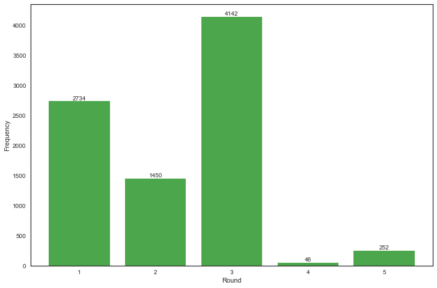

```python
counts = fight_df['round'].value_counts()
plt.figure(figsize=(12,8))
plt.bar(counts.index, counts.values, alpha=.7, color='g')
plt.xlabel('Round')
plt.ylabel('Frequency')
for x,y in zip(counts.index, counts.values):
    plt.text(x, y, y, ha='center', va='bottom')
plt.show()
```

### Method and Win/Loss

```python
fight_df['method'].value_counts()
```

```
Decision      3732
KO/TKO        2790
Submission    1850
TKO            130
Overturned      68
Could           26
DQ              24
Other            4
Name: method, dtype: int64
```

The "TKO", "Could" and "Other" immedietely jump out at me as categories worth exploring. I have no idea what the "Could" or "Other" categories represent. I'm guessing the first is a typo but I'll have to do some research to see what's going on there. I'm also curious as to why they placed KO/TKO and TKO into separate groups. I'll have to research that as well to see if we can consolidate the two categories.

```python
display(fight_df[fight_df.method=='Could'].tail())
display(fight_df[fight_df.method=='Other'])
display(fight_df[fight_df.method=='TKO'].tail())
```

[output not shown]

After doing a little market research and totally not wasting time by watching UFC fights, it looks like the "Could" category stands for no contest, "Other" stands for draws and "TKO" stands for fights where one fighter could not continue due to injury. Each of these scenarios present different challenges. Before going further, let's change "Could" to "No Contest", "Other" to "Draw" and change TKO to "Injury".

```python
fight_df.loc[fight_df.method=='Could', 'method'] = "No Contest"
fight_df.loc[fight_df.method=='TKO', "method"] = "Injury"
fight_df.loc[fight_df.method=='Other', "method"] = "Draw"
```

Fights that stop due to injury are usually fights in which one fighter has been beating his opponent so badly, they had to stop the fight because the opponent couldn't continue. I'll probably do some more market research later, but right now I see that as a win. The goal is to beat up the other fighter, so mission accomplished. I don't know if I'll combine that category with TKO/KO's, but it's a valid win.

No contests and draws, however are a different story. Neither one demonstrates that one side dominated the other and in many cases they are the result of luck. Because of this, they will most likely be dropped from the dataset before building any models.

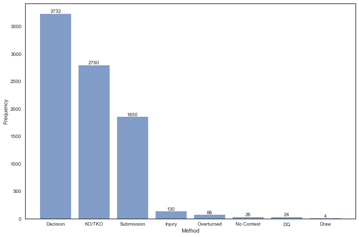

```python
counts = fight_df['method'].value_counts()
plt.figure(figsize=(12,8))
plt.bar(range(len(counts.index)), counts.values, alpha=.7)
plt.xlabel('Method')
plt.ylabel('Frequency')
plt.xticks(range(len(counts.index)), counts.index)
for x,y in zip(range(len(counts.index)), counts.values):
    plt.text(x, y, y, ha='center', va='bottom')
plt.show()
```

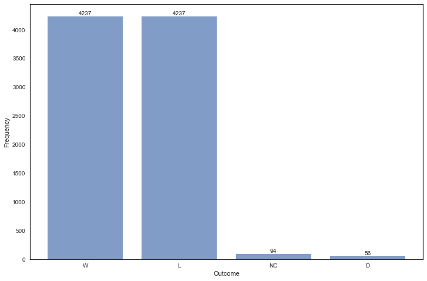

```python
counts = fight_df['win/loss'].value_counts()
plt.figure(figsize=(12,8))
plt.bar(range(len(counts.index)), counts.values, alpha=.7)
plt.xlabel('Outcome')
plt.ylabel('Frequency')
plt.xticks(range(len(counts.index)), counts.index)
for x,y in zip(range(len(counts.index)), counts.values):
    plt.text(x, y, y, ha='center', va='bottom')
plt.show()
```

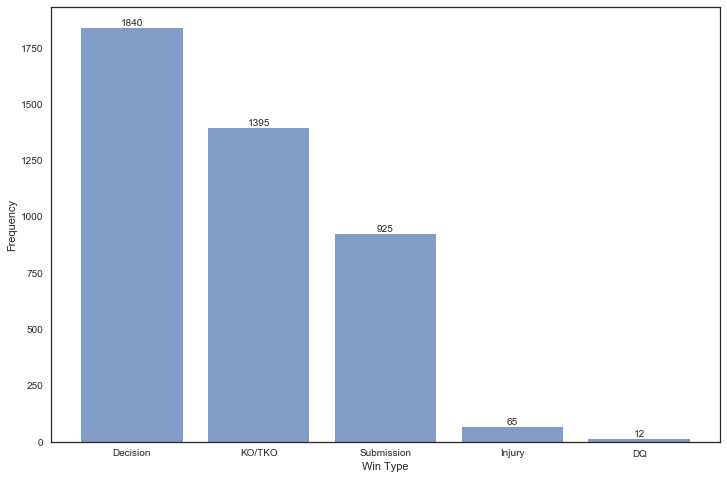

```python
counts = fight_df[fight_df['win/loss']=='W'].method.value_counts()
plt.figure(figsize=(12,8))
plt.bar(range(len(counts.index)), counts.values, alpha=.7)
plt.xlabel('Win Type')
plt.ylabel('Frequency')
plt.xticks(range(len(counts.index)), counts.index)
for x,y in zip(range(len(counts.index)), counts.values):
    plt.text(x, y, y, ha='center', va='bottom')
plt.show()
```

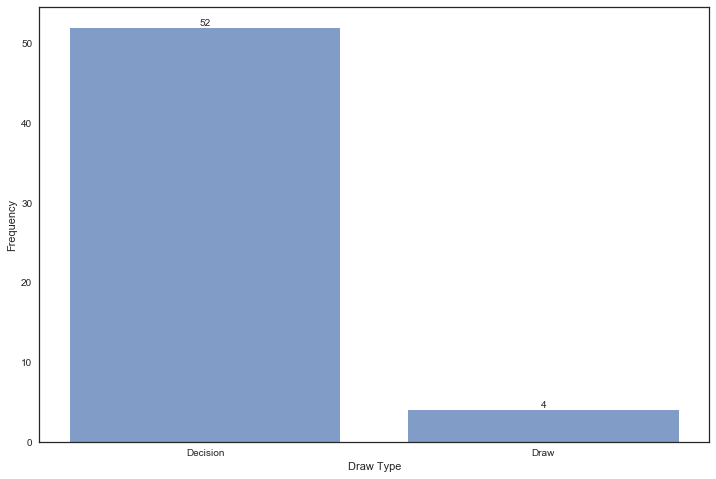

```python
counts = fight_df[fight_df['win/loss']=='D'].method.value_counts()
plt.figure(figsize=(12,8))
plt.bar(range(len(counts.index)), counts.values, alpha=.7)
plt.xlabel('Draw Type')
plt.ylabel('Frequency')
plt.xticks(range(len(counts.index)), counts.index)
for x,y in zip(range(len(counts.index)), counts.values):
    plt.text(x, y, y, ha='center', va='bottom')
plt.show()
```

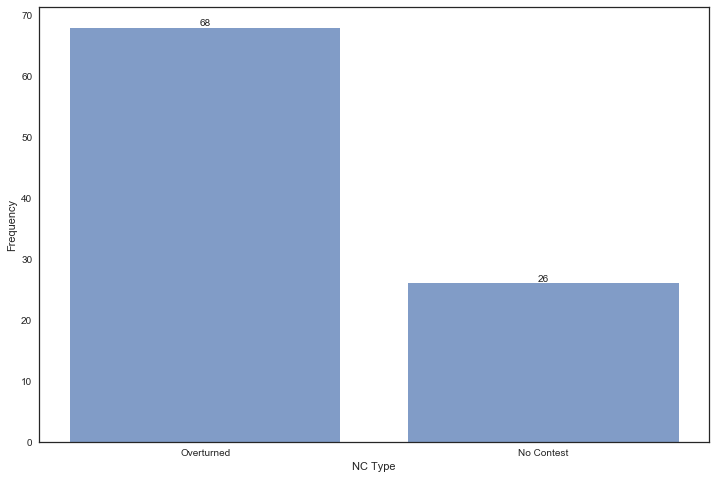

```python
counts = fight_df[fight_df['win/loss']=='NC'].method.value_counts()
plt.figure(figsize=(12,8))
plt.bar(range(len(counts.index)), counts.values, alpha=.7)
plt.xlabel('NC Type')
plt.ylabel('Frequency')
plt.xticks(range(len(counts.index)), counts.index)
for x,y in zip(range(len(counts.index)), counts.values):
    plt.text(x, y, y, ha='center', va='bottom')
plt.show()
```

### Clean Wins

Let's restrict our view to wins that result from one of the following:

1. Judge's Decision
2. KO/TKO
3. Submission
4. Injury

These are situations where one fighter was able to prove their dominance over another through their fighting skill. The remaining categories are at best the result of random chance and not relevant to our interests:

1. Overturned
2. No Contest ['method']
3. DQ
4. Draw
5. NC ['win/loss']

If we want to build a classifier that distinguishes between winners and losers, we should look at fights based on factors that are within their control.

```python
fight_df = fight_df[(fight_df['win/loss'] == 'W') | (fight_df['win/loss'] == 'L')]
fight_df = fight_df[(fight_df.method != 'Overturned') & (fight_df.method != 'No Contest') & (fight_df.method != 'DQ')]
fight_df.method.value_counts()
```

```
Decision      3680
KO/TKO        2790
Submission    1850
Injury         130
Name: method, dtype: int64
```

## Heatmap

Let's start off with a bird's eye view of the data. We'll use a heatmap to spot correlations and make quick inferences about the dataset before diving into the individual variables.

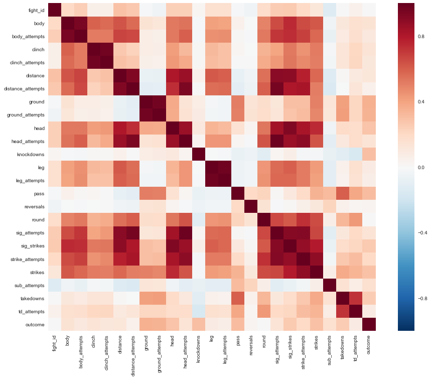

```python
corrmat = fight_df.corr()
plt.figure(figsize=(16,12))
sns.heatmap(corrmat, square=True)
plt.show()
```

Wow, there appears to be a strong corrleation between every strike and strike attempt. Wayne Gretsky was right, "You miss 100% of the shots you don't take." There are several other related variables scattered throughout the dataset. It seems significant attempts, head attempts and distance attempts are all closely related. Also of note is the relationship between the number of passes and the number of takedowns. Interestingly, the number of knowckdowns does not seem to be strongly correlated with any particular variable. There is a small connection between knockdowns, win/loss and head strikes.

There does not appear to be a lot of negative correlations. The only small standouts are sub attempts to fight_id, knockdowns to takedown attempts and sub attempts to distance strikes. The last two make sense to a certain extent. If a a fighter is a good striker, they'd have little reason to try to take someone their opponent down and if they're they're a submission artist they would probably throw fewer distance strikes. The relationship between sub attempts and fight_id doesn't make as much sense to me right now. In the beginning, not many people were familiar with bjj so I would expect the number of submission attempts to grow over time. I'll have to take a closer look at that later.

Applying a log transform yields...

```python
cols = [u'body', u'body_attempts', u'clinch', u'clinch_attempts', u'distance',
       u'distance_attempts', u'ground', u'ground_attempts',
       u'head', u'head_attempts', u'knockdowns', u'leg', u'leg_attempts',
       u'pass', u'reversals', u'sig_attempts', u'sig_strikes',
       u'strike_attempts', u'strikes', u'sub_attempts', u'takedowns',
       u'td_attempts']

fight_logs = fight_df.copy()
fight_logs.loc[:, cols] = fight_df[cols] + 1
fight_logs.loc[:, cols] = fight_logs[cols].apply(np.log)
```

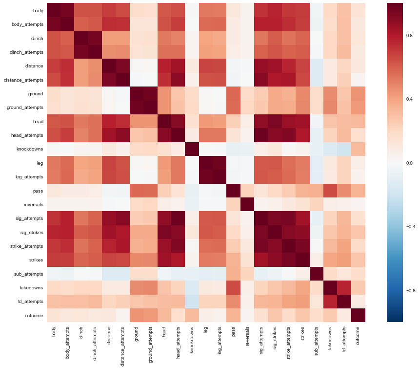

```python
corrmat = fight_logs.drop(['fight_id', 'round'], axis=1).corr()
plt.figure(figsize=(16,12))
sns.heatmap(corrmat, square=True)
plt.show()
```

## Strike Targets

I want to go through each of these variables to get a sense of each one. We'll use histograms, distribution plots, barplots, violin plots heatmaps, and more to get a better feel for the data.

### Body

First up is body strikes.

```python
fight_df.body.describe()
```

```
count    8450.000000
mean        5.954556
std         7.166225
min         0.000000
25%         1.000000
50%         4.000000
75%         9.000000
max        92.000000
Name: body, dtype: float64
```

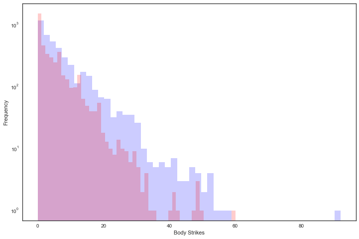

```python
#upper_limit = np.percentile(fight_df['body'].values, 99)
#fight_df.loc[fight_df.body>upper_limit, 'body'] = upper_limit
plt.figure(figsize=(12,8))
plt.hist(
    'body',
    data=fight_df[fight_df['win/loss']=='W'],
    log=True,
    bins=50,
    alpha=.2,
    color='b'
)
plt.hist(
    'body',
    data=fight_df[fight_df['win/loss']=='L'],
    log=True,
    bins=50,
    alpha=.2,
    color='r'
)
plt.xlabel('Body Strikes')
plt.ylabel('Frequency')
plt.show()
```

It might make sense to plot the number of body strikes vs attempts since they may be correlated. Let's see what the data looks like.

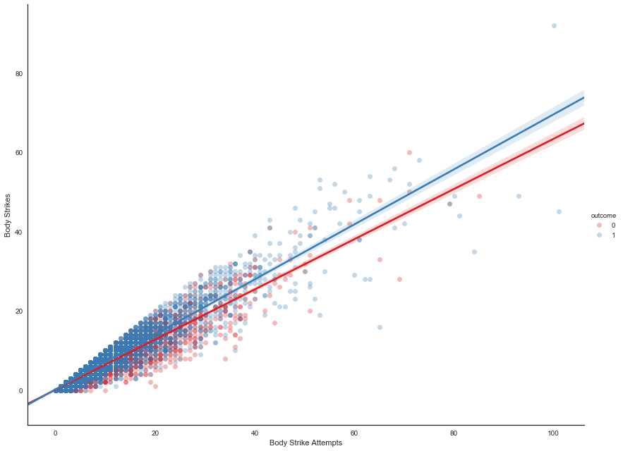

```python
#upper_limit = np.percentile(fight_df['body_attempts'].values, 99)
#fight_df.loc[fight_df.body>upper_limit, 'body_attempts'] = upper_limit
#plt.figure(figsize=(12,8))
sns.lmplot('body_attempts', 'body',
           data=fight_df,
           scatter_kws={'alpha':.3},
           hue='outcome',
           palette='Set1',
           size=9,
           aspect=1.3)
plt.xlabel("Body Strike Attempts")
plt.ylabel("Body Strikes")
plt.show()
```

Body strikes and body strike attempts are definitely positively correlated. I'm guessing it'll be the same for the other categories.

### Head

```python
fight_df['head'].describe()
```

```
count    8450.000000
mean       19.019172
std        18.785579
min         0.000000
25%         5.000000
50%        14.000000
75%        27.000000
max       199.000000
Name: head, dtype: float64
```

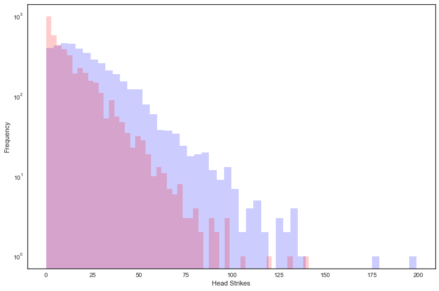

```python
plt.figure(figsize=(12,8))
plt.hist(
    'head',
    data=fight_df[fight_df['win/loss']=='W'],
    log=True,
    bins=50,
    alpha=.2,
    color='b'
)
plt.hist(
    'head',
    data=fight_df[fight_df['win/loss']=='L'],
    log=True,
    bins=50,
    alpha=.2,
    color='r'
)
plt.xlabel('Head Strikes')
plt.ylabel('Frequency')
plt.show()
```

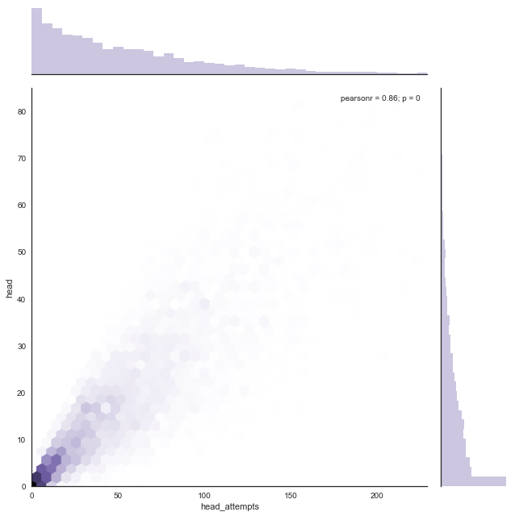

```python
upper_landed = np.percentile(fight_df['head'].values, 99)
#fight_df.loc[fight_df['head']>upper_landed, 'head'] = upper_landed
upper_attempts = np.percentile(fight_df['head_attempts'].values, 99)
#fight_df.loc[fight_df.head_attempts>upper_attempts, 'head_attempts'] = upper_attempts
sns.jointplot(
    'head_attempts',
    'head',
    data=fight_df[(fight_df['head']<upper_landed) & (fight_df.head_attempts<upper_attempts)],
    size=9,
    kind='hex',
    color=color[3]
)
plt.show()
```

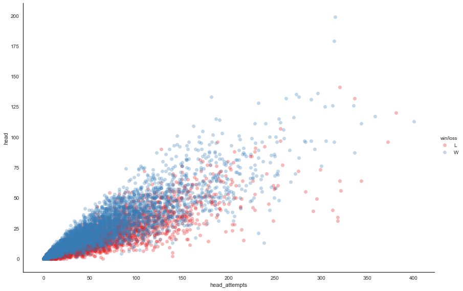

```python
# plt.figure(figsize=(12,8))
sns.lmplot(
    'head_attempts',
    'head',
    data=fight_df,
    hue='win/loss',
    palette='Set1',
    scatter_kws={'alpha':.3},
    fit_reg=False,
    size=8,
    aspect=1.5
)
plt.show()
```

### Leg

```python
fight_df.leg.describe()
```

```
count    8450.000000
mean        4.883787
std         6.802733
min         0.000000
25%         0.000000
50%         2.000000
75%         7.000000
max        75.000000
Name: leg, dtype: float64
```

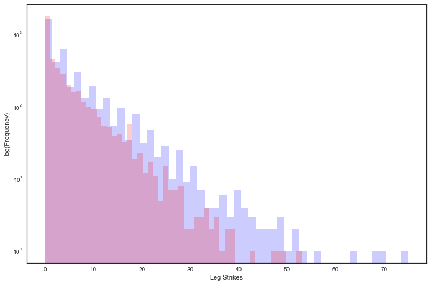

```python
plt.figure(figsize=(12,8))
plt.hist(
    'leg',
    data=fight_df[fight_df['win/loss']=='W'],
    log=True,
    bins=50,
    alpha=.2,
    color='b'
)
plt.hist(
    'leg',
    data=fight_df[fight_df['win/loss']=='L'],
    log=True,
    bins=50,
    alpha=.2,
    color='r'
)
plt.xlabel('Leg Strikes')
plt.ylabel('log(Frequency)')
plt.show()
```

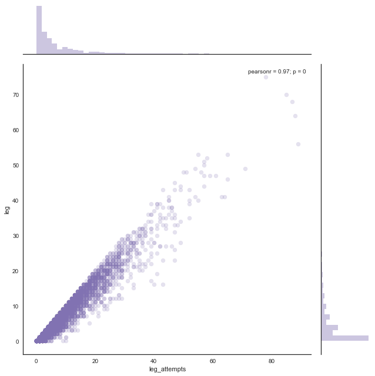

```python
sns.jointplot('leg_attempts', 'leg', data=fight_df, size=9, alpha=.2, color=color[3])
plt.show()
```

## Strike Types

### Ground and Pound

Let's take a look at the number of ground strikes attempted and landed across the distribution.

```python
fight_df.ground.describe()
```

```
count    8450.000000
mean        5.195503
std         9.063701
min         0.000000
25%         0.000000
50%         1.000000
75%         7.000000
max       100.000000
Name: ground, dtype: float64
```

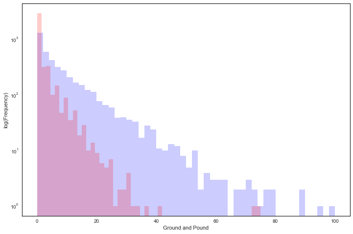

```python
plt.figure(figsize=(12,8))
plt.hist(
    'ground',
    data=fight_df[fight_df['win/loss']=='W'],
    log=True,
    bins=50,
    alpha=.2,
    color='b'
)
plt.hist(
    'ground',
    data=fight_df[fight_df['win/loss']=='L'],
    log=True,
    bins=50,
    alpha=.2,
    color='r'
)
plt.xlabel('Ground and Pound')
plt.ylabel('log(Frequency)')
plt.show()
```

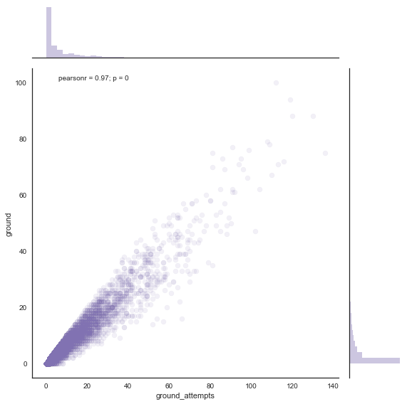

```python
sns.jointplot(
    'ground_attempts',
    'ground',
    data = fight_df,
    size=8,
    alpha=.1,
    color=color[3])
plt.show()
```

### Distance

```python
fight_df.distance.describe()
```

```
count    8450.000000
mean       19.490059
std        22.547213
min         0.000000
25%         3.000000
50%        12.000000
75%        27.000000
max       228.000000
Name: distance, dtype: float64
```

That's quite a range! The mean is 19 but someone landed 228 strikes from distance. I would not want to be on the receiving end of that. Let's take a look at how the distance strikes landed line up with the distance strike attempts.

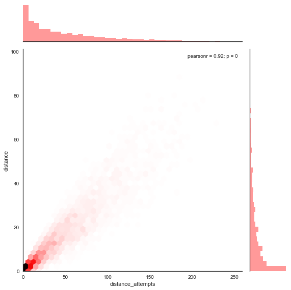

```python
upper_landed = np.percentile(fight_df['distance'].values, 99)
# fight_df.loc[fight_df.distance>upper_landed, 'distance'] = upper_landed
upper_attempts = np.percentile(fight_df['distance_attempts'].values, 99)
# fight_df.loc[fight_df.distance_attempts>upper_attempts, 'distance_attempts'] = upper_attempts
sns.jointplot(
    'distance_attempts',
    'distance',
    data=fight_df[(fight_df.distance<upper_landed)&(fight_df.distance_attempts<upper_attempts)],
    kind='hex',
    size=8,
    color='r'
)
plt.show()
```

### Clinch

```python
fight_df.clinch.describe()
```

```
count    8450.000000
mean        5.171953
std         7.518794
min         0.000000
25%         0.000000
50%         2.000000
75%         7.000000
max        95.000000
Name: clinch, dtype: float64
```

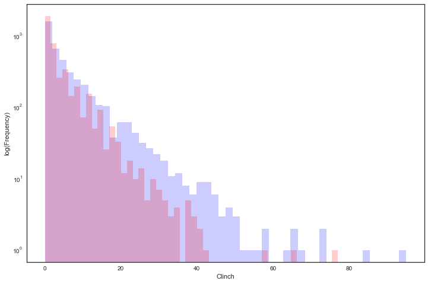

```python
plt.figure(figsize=(12,8))
plt.hist(
    'clinch',
    data=fight_df[fight_df['win/loss']=='W'],
    log=True,
    bins=50,
    alpha=.2,
    color='b'
)
plt.hist(
    'clinch',
    data=fight_df[fight_df['win/loss']=='L'],
    log=True,
    bins=50,
    alpha=.2,
    color='r'
)
plt.xlabel('Clinch')
plt.ylabel('log(Frequency)')
plt.show()
```

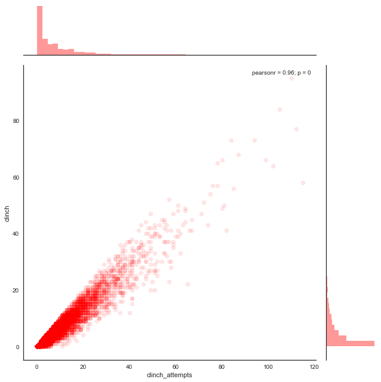

```python
sns.jointplot('clinch_attempts', 'clinch', data=fight_df, alpha=.1, size=9, color='r')
plt.show()
```

### Significant Strikes

```python
fight_df.sig_strikes.describe()
```

```
count    8450.000000
mean       29.857515
std        26.822008
min         0.000000
25%         9.000000
50%        23.000000
75%        43.000000
max       238.000000
Name: sig_strikes, dtype: float64
```

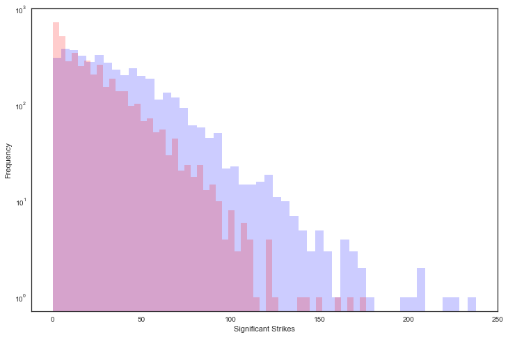

```python
plt.figure(figsize=(12,8))
plt.hist(
    'sig_strikes',
    data=fight_df[fight_df['win/loss']=='W'],
    log=True,
    bins=50,
    alpha=.2,
    color='b'
)
plt.hist(
    'sig_strikes',
    data=fight_df[fight_df['win/loss']=='L'],
    log=True,
    bins=50,
    alpha=.2,
    color='r'
)
plt.xlabel('Significant Strikes')
plt.ylabel('Frequency')
plt.show()
```

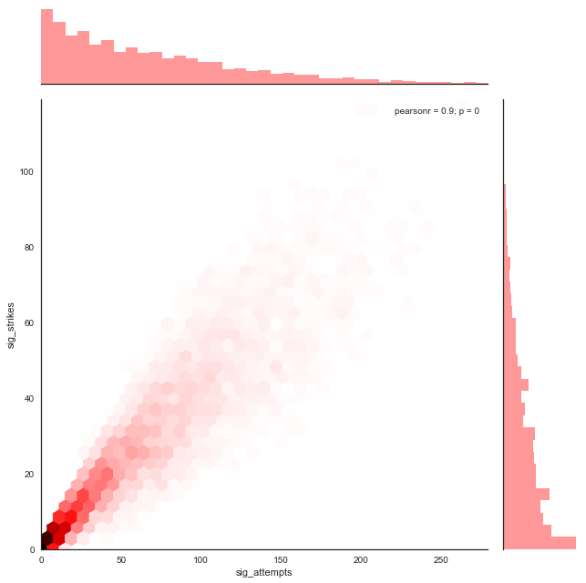

```python
upper_landed = np.percentile(fight_df['sig_strikes'].values, 99)
# fight_df.loc[fight_df['sig_strikes']>upper_landed, 'sig_strikes'] = upper_landed
upper_attempts = np.percentile(fight_df['sig_attempts'].values, 99)
# fight_df.loc[fight_df.sig_attempts>upper_attempts, 'sig_attempts'] = upper_attempts
sns.jointplot(
    'sig_attempts',
    'sig_strikes',
    data=fight_df[(fight_df.sig_strikes<upper_landed)&(fight_df.sig_attempts<upper_attempts)],
    size=9,
    kind='hex',
    color='r')
plt.show()
```

### Overall Strikes

```python
fight_df.strikes.describe()
```

```
count    8450.000000
mean       48.601183
std        41.364941
min         0.000000
25%        16.000000
50%        40.000000
75%        70.000000
max       361.000000
Name: strikes, dtype: float64
```

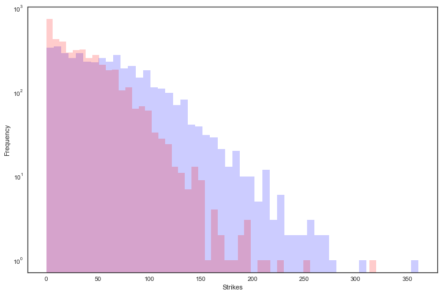

```python
plt.figure(figsize=(12,8))
plt.hist(
    'strikes',
    data=fight_df[fight_df['win/loss']=='W'],
    log=True,
    bins=50,
    alpha=.2,
    color='b'
)
plt.hist(
    'strikes',
    data=fight_df[fight_df['win/loss']=='L'],
    log=True,
    bins=50,
    alpha=.2,
    color='r'
)
plt.xlabel('Strikes')
plt.ylabel('Frequency')
plt.show()
```

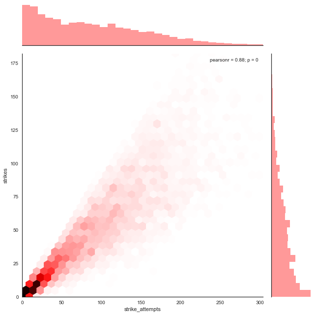

```python
upper_landed = np.percentile(fight_df['strikes'].values, 99)
# fight_df.loc[fight_df['strikes']>upper_landed, 'strikes'] = upper_landed
upper_attempts = np.percentile(fight_df['strike_attempts'].values, 99)
# fight_df.loc[fight_df.strike_attempts>upper_attempts, 'strike_attempts'] = upper_attempts
sns.jointplot(
    'strike_attempts',
    'strikes',
    data=fight_df[(fight_df.strikes<upper_landed)&(fight_df.strike_attempts<upper_attempts)],
    size=9,
    kind='hex',
    color='r')
plt.show()
```

## Grappling

### Submissions

This variable will require a bit of reworking. The submission variable is binary, while the submissions attempted is discrete. That makes sense of course, becaues you can't submit someone more than once in a match by definition (unless you count twitter wars). So for this aspect, let's take at the distribution of submissions attempts vs the method used. My theory is that submission attempts are higher in fights that end that way, but let's take a look at the data!

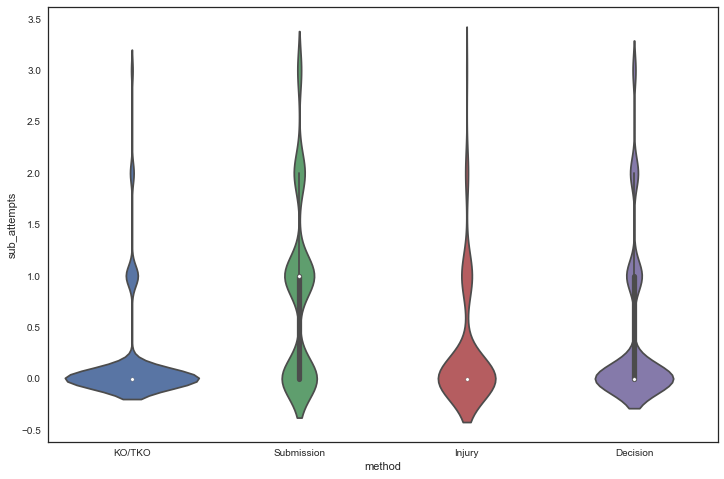

```python
upper_attempts = np.percentile(fight_df.sub_attempts, 99)
plt.figure(figsize=(12,8))
sns.violinplot(
    x="method",
    y="sub_attempts",
    data=fight_df[(fight_df.sub_attempts<upper_attempts)])
plt.show()
```

What an interesting distribution! And just as expected, fights that end in submission have a higher percentage of submisssion attempts greater than zero. Interestingly, fights that end in decision aren't heavy on submission attempts. This could be due to the nature of how fights are scored overall since submission attempts do not give a fighter as many points as strikes.

Another thing that jumped out at me is the number of submission wins with zero submission attempts. I would expect that every fight that ends in submission contained at least one submission attempt, but I'm guessing they count submission due to strikes as well.

### Passes

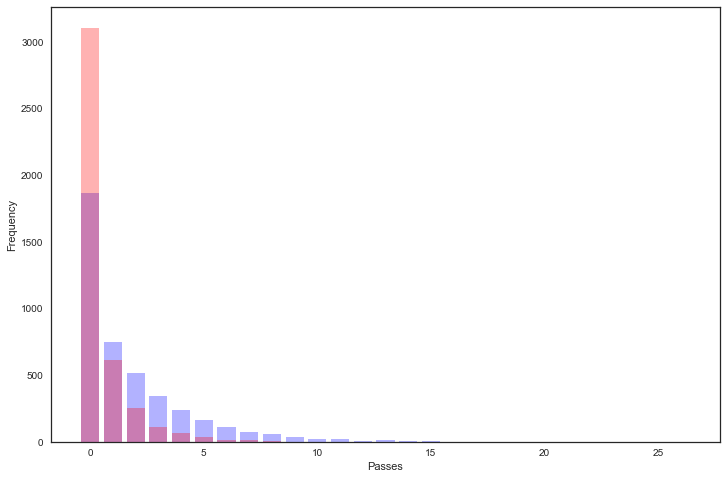

```python
w_counts = fight_df.loc[fight_df['win/loss']=='W','pass'].value_counts()
l_counts = fight_df.loc[fight_df['win/loss']=='L','pass'].value_counts()
plt.figure(figsize=(12,8))
plt.bar(
    w_counts.index,
    w_counts.values,
    alpha=.3,
    color='b'
)
plt.bar(
    l_counts.index,
    l_counts.values,
    alpha=.3,
    color='r'
)
plt.xlabel('Passes')
plt.ylabel('Frequency')
'''
for x,y in zip(counts.index, counts.values):
    plt.text(x, y, y, ha='center', va='bottom')
'''
plt.show()
```

### Reversals

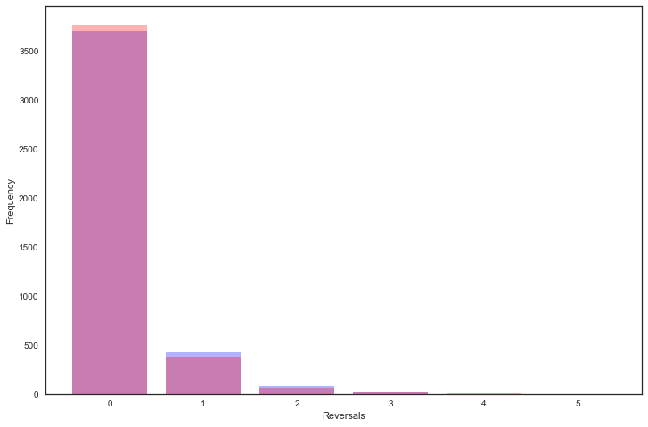

```python
w_counts = fight_df.loc[fight_df['win/loss']=='W','reversals'].value_counts()
l_counts = fight_df.loc[fight_df['win/loss']=='L','reversals'].value_counts()
plt.figure(figsize=(12,8))
plt.bar(
    w_counts.index,
    w_counts.values,
    alpha=.3,
    color='b'
)
plt.bar(
    l_counts.index,
    l_counts.values,
    alpha=.3,
    color='r'
)
plt.xlabel('Reversals')
plt.ylabel('Frequency')
'''
for x,y in zip(counts.index, counts.values):
    plt.text(x, y, y, ha='center', va='bottom')
'''
plt.show()
```

### Takedowns

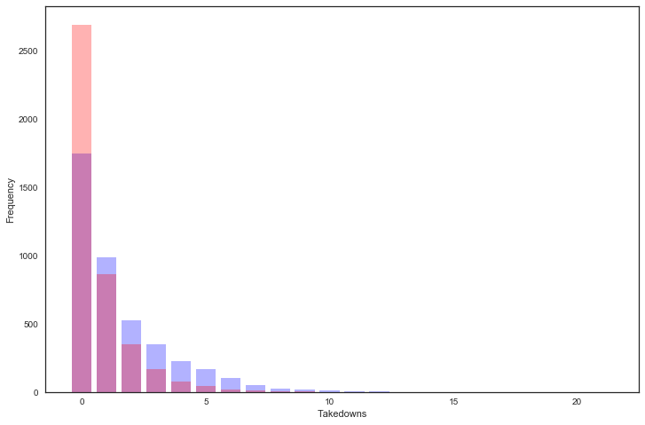

```python
w_counts = fight_df.loc[fight_df['win/loss']=='W','takedowns'].value_counts()
l_counts = fight_df.loc[fight_df['win/loss']=='L','takedowns'].value_counts()
plt.figure(figsize=(12,8))
plt.bar(
    w_counts.index,
    w_counts.values,
    alpha=.3,
    color='b'
)
plt.bar(
    l_counts.index,
    l_counts.values,
    alpha=.3,
    color='r'
)
plt.xlabel('Takedowns')
plt.ylabel('Frequency')
plt.show()
```

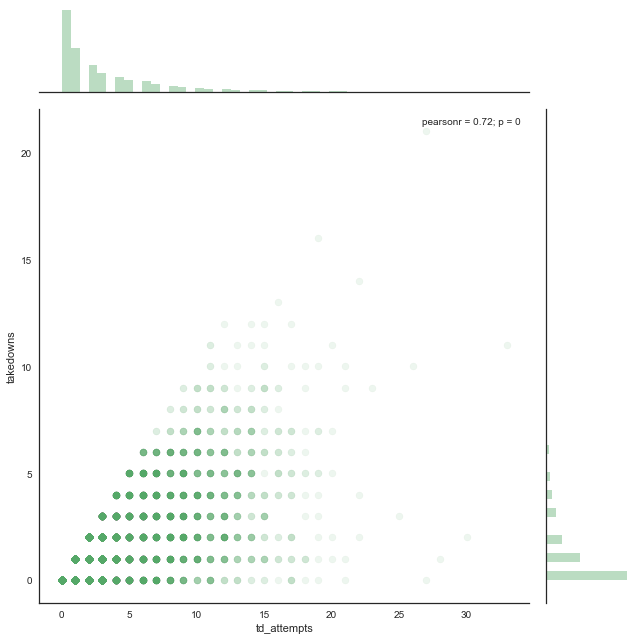

```python
upper_landed = np.percentile(fight_df['takedowns'].values, 99)
upper_attempts = np.percentile(fight_df['td_attempts'].values, 99)
sns.jointplot(
    'td_attempts',
    'takedowns',
#     data=fight_df[(fight_df.takedowns<=upper_landed)&(fight_df.td_attempts<=upper_attempts)],
    data=fight_df,
    size=9,
    alpha=.1,
    color=color[1])
#     kind='hex',
#     marginal_kws={'bins':50})
plt.show()
```

## Knockdowns

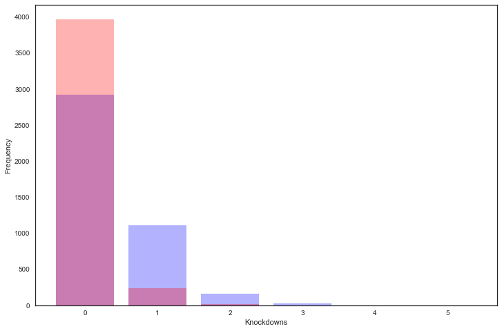

```python
w_counts = fight_df.loc[fight_df['win/loss']=='W','knockdowns'].value_counts()
l_counts = fight_df.loc[fight_df['win/loss']=='L','knockdowns'].value_counts()
plt.figure(figsize=(12,8))
plt.bar(
    w_counts.index,
    w_counts.values,
    alpha=.3,
    color='b'
)
plt.bar(
    l_counts.index,
    l_counts.values,
    alpha=.3,
    color='r'
)
plt.xlabel('Knockdowns')
plt.ylabel('Frequency')
plt.show()
```

## Referees and Fighters

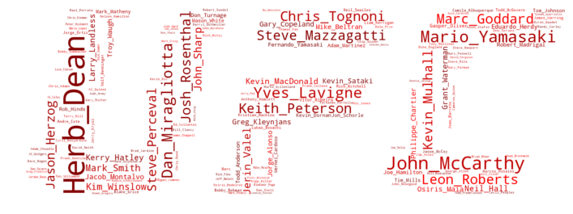

```python
def grey_color_func(word, font_size, position, orientation, random_state=None,
                    **kwargs):
    return "hsl(0, 100%, {}%)".format(random.randint(25, 50))

# Extract referee text from fight_df
text = " ".join("_".join(ref.split()) for ref in fight_df[fight_df.referee.notnull()].referee.tolist())

# read the mask image
ufc_mask = np.array(Image.open("images/UFC_Logo.png"))

wc = WordCloud(background_color="white", mask=ufc_mask, random_state=42)
# generate word cloud
wc.generate(text)

wc.recolor(color_func=grey_color_func, random_state=3)

# store to file
wc.to_file("images/ufc_red_wordcloud.png")

# show
plt.figure(figsize=(12,8))
plt.imshow(wc, interpolation='bilinear')
plt.axis("off")
plt.show()
```

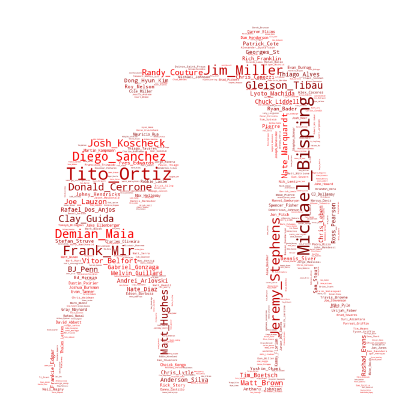

```python
def custom_color_func(word, font_size, position, orientation, random_state=None,
                    **kwargs):
    return "hsl(0, 100%, {}%)".format(random.randint(25, 50))

# Extract referee text from fight_df
text = " ".join("_".join(fighter.split()) for fighter in fight_df[fight_df.name.notnull()].name.tolist())

# read the mask image
fighter_mask = np.array(Image.open("images/shadowboxing.jpg"))


wc = WordCloud(max_words=1000, background_color="white", mask=fighter_mask, random_state=1)
# generate word cloud
wc.generate(text)

wc.recolor(color_func=custom_color_func, random_state=3)

# store to file
wc.to_file("images/ufc_fighter_red_wordcloud.png")

# show
plt.figure(figsize=(14,12))
plt.imshow(wc.recolor(color_func=custom_color_func, random_state=3), interpolation='bilinear')
plt.axis("off")
plt.show()
```